# Day 6 : Performance Evaluation

Angie Hsu

2019-08-23

> 本日重點
1. 了解衡量迴歸預測模型成效的常見指標
2. 如何透過 R 得出衡量結果- 直接套用 package v.s. 直接計算
3. 如何選擇模型上傳 Kaggle 預測結果

> 若模型的預測值與實際值的差異太大，會造成“損失”

> 例如: 為了制定價格而作價格迴歸預測模型
- 預測價格 < 實際價格: 制定的價格過低，使收回的金額降低
- 預測價格 > 實際價格: 制定的價格過高，購買的人數減少，也會使收回的金額降低

## Part 1 : 迴歸預測模型常見衡量指標

為了最小化損失，希望模型預測值與實際值的差異越小越好，而不同的損失函數衍生出不同的衡量指標，以下介紹兩個常見的衡量指標

- RMSE: Root-Mean-Square-Error，均方根誤差，為 MSE 的開根號，誤差的結果能跟資料是相同單位，便於計算，為現行最常被使用的衡量指標之一，RMSE 越小，模型成效越好。
- MAE: Mean Absolute Error，平均絕對誤差，絕對誤差的平均值，平均絕對誤差能更好地反映預測值誤差的實際情況，MAE 越小，模型成效越好。

還有另一個常見的衡量指標用可於判斷模型的解釋力:

- R-Squared: 又稱為決定係數，反映預測因變數的全部變異能通過迴歸關係被模型解釋的比例，介於 0~1。如果結果是 0，就說明模型預測不能預測因變數，而若模型解釋力越高，R-Squared 的值就越接近於 1。R-Squared 反映的是”大概”有多準，因為，”隨著樣本數量的增加”，R-Squared必然增加，無法真正定量說明準確程度，只能大概定量。

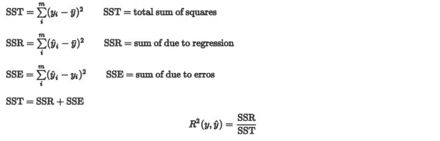

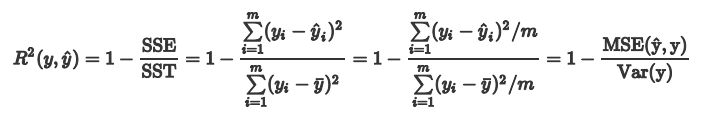

## Part 2 : Model Evaluation in R

為了稍後要用 R 分別得出常見衡量指標 RMSE、MAE、R-Squared 的數值，要先設定環境並跑模型、存取用 validation data 跑好的預測結果(此處僅是舉例)

```r
##設定環境
#setwd(dir) #設定working directory的存放位置
# MAC : setwd("/Users/rladiestaipei/R_DragonBall/")
# Windows : setwd("C://Users/rladiestaipei/Desktop/R_DragonBall/")

#安裝套件(僅需執行一次)
#install.packages(c("caTools", "caret", "dplyr", 'xgboost',"Metrics"),
#                dependencies = TRUE)

#load packages
library(caTools)
library(caret)
library(dplyr)
library(xgboost)
library(Metrics)
```

```r
#讀取資料
dataset <- read.csv("train_new.csv")

# select features you want to put in models
# 這邊請根據前面幾天所學的去放入你認為重要的變數(如下只是範例)
dataset <- dataset %>% dplyr::select(SalePrice_log, X1stFlrSF, TotalBsmtSF,
                                     YearBuilt, LotArea, Neighborhood, GarageCars, GarageArea, GrLivArea_stand,
                                     MasVnrArea_stand, LotFrontage_log, is_Fireplace, TotalBathrooms, TotalSF_stand)

# Splitting the dataset into the Training set and Validation set
# library(caTools)
set.seed(1)
split <- sample.split(dataset$SalePrice_log, SplitRatio = 0.8)
training_set <- subset(dataset, split == TRUE)
val_set <- subset(dataset, split == FALSE)
```

先跑 **Linear Regression**

```r
##Linear Regression
# Fitting Multiple Linear Regression to the Training set
Reg <- lm(formula = SalePrice_log ~ ., data = training_set)

#Get prediction of validation set
pred_reg <- predict(Reg, newdata = val_set)
```

再跑一個**XGBoost**

```r
##XGBoost
# library(xgboost)
# 因XGBoost是吃matrix的格式，故須將所有資料皆轉換為數值型，存入矩陣中

# transfer all feature to numeric
training_set_new <- training_set %>% dplyr::select(-SalePrice_log)
val_set_new <- val_set %>% dplyr::select(-SalePrice_log)
cat_index <- which(sapply(training_set_new, class) == "factor")
training_set_new[cat_index] <- lapply(training_set_new[cat_index], as.numeric)
val_set_new[cat_index] <- lapply(val_set_new[cat_index], as.numeric)

# put testing & training data into two seperates Dmatrixs objects
labels <- training_set$SalePrice_log
dtrain <- xgb.DMatrix(data = as.matrix(training_set_new),label = labels)
dval <- xgb.DMatrix(data = as.matrix(val_set_new))

# set parameters
param <-list(objective = "reg:linear",
             booster = "gbtree",
             eta = 0.01, #default = 0.3
             gamma=0,
             max_depth=3, #default=6
             min_child_weight=4, #default=1
             subsample=1,
             colsample_bytree=1
)

# Fitting XGBoost to the Training set
set.seed(1)
xgb_base <- xgb.train(params = param, data = dtrain, nrounds = 3000
                       #watchlist = list(train = dtrain, val = dval),
                       #print_every_n = 50, early_stopping_rounds = 300
)

#Get prediction of validation set
pred_xgb_base <- predict(xgb_base, dval)
```

**RMSE** 複習在 Day4 & Day5 學過的，曾經分別用2個不同的套件計算過 RMSE ( Day4 的Metrics & Day5 套件 caret 中的 ModelMetrics )

Caculate RMSE Metrics Package (Day4)

```r
# Linear Regression
rmse(val_set$SalePrice_log, pred_reg)
```

```
[1] 0.1531402
```

```r
# XGBoost
rmse(val_set$SalePrice_log, pred_xgb_base)
```

```
[1] 0.1442952
```

也可以還原公式, 直接計算 MSE & RMSE, 以 XGBoost 預測結果為例

先算 MSE

```r
mse_cal <- mean((pred_xgb_base - val_set$SalePrice_log)**2)
print(mse_cal)
```

```
[1] 0.0208211
```

再算 RMSE

```r
rmse_cal <- sqrt(mse_cal)
print(rmse_cal)
```

```
[1] 0.1442952
```

```r
# 計算結果相同, 0.1442952 = 0.1442952
```

**MAE**

```r
# XGBoost - Metrics Package
mae(val_set$SalePrice_log, pred_xgb_base)
```

```
[1] 0.09977234
```

其他衡量指標的計算可直接套用 [Metrics Package](https://github.com/mfrasco/Metrics) 或直接計算

## Part 3 : 選擇模型上傳 Kaggle 結果檔

本次 Kaggle 競賽採用的衡量基準為 testset log(SalePrice) 預測值與真實值的 RMSE –> 越小越好 –> 因此要選取 Validation set RMSE 最小的模型

- Steps:
  1. 套用最好的模型跑 testset
  2. 模型的預測標的 Sale_Price 做過 log 轉換，若最後上傳時要用 exp 轉換回原始的 Sale Price [參考連結](https://www.kaggle.com/paultimothymooney/get-your-model-ready-to-submit?fbclid=IwAR1Gi8EfElGa8S63jbAVxyO8rDPcP7kGxL_wq2n0N5l4haGJTIzlplshtL8)

```r
# 還原log的範例
x <- 87
x_log <- log(x)
exp(x_log)
```

```
[1] 87
```

## 參考資料

1. [ML Regression - Assessing Performance](https://www.coursera.org/learn/ml-regression/home/week/3)
2. [Prepare Submission File](https://www.kaggle.com/paultimothymooney/get-your-model-ready-to-submit?fbclid=IwAR1Gi8EfElGa8S63jbAVxyO8rDPcP7kGxL_wq2n0N5l4haGJTIzlplshtL8)

## 本日小挑戰

> 二選一  
> A. 找出你最好的模型，上傳你的 testset 預測結果到 Kaggle 平台上吧! 並記錄下 Kaggle 幫你算出來的實際 RMSE 是多少  
> B. 如何得出模型的 R-Squared